# **Project Idea (Part A)**

### The safety of a car is one of the key considerations when evaluating and purchasing a car. This is especially important in the DMV area, where congested traffic and irratic driving behavior is normal and expected. With the negative perception of drivers in the DMV area, it's important to target the incident reports occurring in this region. For this reason, I've decided to evaluate the Montgomery County Crash Reporting Incident Dataset to identify the failure points of popular cars in the DMV region. By understanding the metrics in this dataset, we can obtain a different perspective on car safety tests by evaluating real crash data and not simulated crash tests. The main objective here is to identify the vunerabilities of popular car's in the Montgomery County region using the hundreds of thousands of datapoints collected by Montgomery County Police Department

# **Dataset Curation and Preprocessing (Part B)**

```
Total Data Entries: 210736
Number of Features: 39
Number of Numerical Features: 4
   \-> ['Speed Limit', 'Vehicle Year', 'Latitude', 'Longitude']
Number of Categorical Features: 35
   \-> ['Report Number', 'Local Case Number', 'Agency Name', 'ACRS Report Type', 'Crash Date/Time', 'Route Type', 'Road Name', 'Cross-Street Name', 'Off-Road Description', 'Municipality', 'Related Non-Motorist', 'Collision Type', 'Weather', 'Surface Condition', 'Light', 'Traffic Control', 'Driver Su…
```

|  | Report Number | Local Case Number | Agency Name | ACRS Report Type | Crash Date/Time | Route Type | Road Name | Cross-Street Name | Off-Road Description | Municipality | ... | Vehicle Going Dir | Speed Limit | Driverless Vehicle | Parked Vehicle | Vehicle Year | Vehicle Make | Vehicle Model | Latitude | Longitude | Location |
| --- | --- | --- | --- | --- | --- | --- | --- | --- | --- | --- | --- | --- | --- | --- | --- | --- | --- | --- | --- | --- | --- |
| 0 | MCP3126006X | 250037402 | MONTGOMERY | Injury Crash | 08/21/2025 05:21:00 PM | Maryland (State) Route | NaN | NaN | NaN | NaN | ... | Northbound | 40 | No | No | 2013 | KIA | SOUL | 39.219796 | -77.257416 | (39.219796, -77.25741635) |
| 1 | MCP2349001B | 250037516 | MONTGOMERY | Property Damage Crash | 08/22/2025 10:44:00 AM | Interstate (State) | EISENHOWER MEMORIAL HWY | NaN | NaN | NaN | ... | Northbound | 55 | No | No | 0 | NaN | NaN | 39.180181 | -77.250657 | (39.18018079, -77.25065714) |
| 2 | MCP296500BC | 250033157 | MONTGOMERY | Property Damage Crash | 07/25/2025 11:55:00 AM | Bicycle Route | NaN | NEW HAMPSHIRE AVE (SB/L) NORBECK RD (WB/L) SPE... | NaN | NaN | ... | Westbound | 40 | No | No | 2023 | LEXUS | RX | 39.121219 | -76.988905 | (39.12121898, -76.98890509) |

3 rows × 39 columns

#### From this data preview, we can see that this dataset has 39 features. Of these 39 features, 35 of them are categorical and the other 4 are numerical features. In addition, we have 210,736 entries in this dataset. With the preview alone, we can see that there exist many missing values that will mess up our data analysis and predictions. A good first step would be to handle these badly collected entries.

### Data Source:

#### Montgomery County. (n.d.). Crash Reporting - Incidents data [Dataset].https://data.montgomerycountymd.gov/Public-Safety/Crash-Reporting-Incidents-Data/bhju-22kf/about_data

# **Data Exploration and Summary Statistics (Part C)**

### **Check how unique values vs total values:**

|  | 0 | 1 | 2 | 3 | 4 | 5 | 6 | 7 | 8 | 9 | 10 | 11 | 12 | 13 | 14 | 15 | 16 |
| --- | --- | --- | --- | --- | --- | --- | --- | --- | --- | --- | --- | --- | --- | --- | --- | --- | --- |
| Column Name | Report Number | Local Case Number | Agency Name | ACRS Report Type | Crash Date/Time | Route Type | Road Name | Cross-Street Name | Off-Road Description | Municipality | Related Non-Motorist | Collision Type | Weather | Surface Condition | Light | Traffic Control | Driver Substance Abuse |
| Unique Values | 118843 | 118729 | 10 | 3 | 115943 | 19 | 4789 | 7536 | 13978 | 20 | 28 | 28 | 23 | 21 | 16 | 33 | 20 |
| Total Values | 210736 | 210736 | 210736 | 210736 | 210736 | 190097 | 186385 | 170288 | 19597 | 19126 | 6879 | 210151 | 197380 | 186760 | 209291 | 181648 | 179416 |
| Is Unique | False | False | False | False | False | False | False | False | False | False | False | False | False | False | False | False | False |

|  | 17 | 18 | 19 | 20 | 21 | 22 | 23 | 24 | 25 | 26 | ... | 29 | 30 | 31 | 32 | 33 | 34 | 35 | 36 | 37 | 38 |
| --- | --- | --- | --- | --- | --- | --- | --- | --- | --- | --- | --- | --- | --- | --- | --- | --- | --- | --- | --- | --- | --- |
| Column Name | Non-Motorist Substance Abuse | Person ID | Driver At Fault | Injury Severity | Circumstance | Driver Distracted By | Drivers License State | Vehicle ID | Vehicle Damage Extent | Vehicle First Impact Location | ... | Vehicle Going Dir | Speed Limit | Driverless Vehicle | Parked Vehicle | Vehicle Year | Vehicle Make | Vehicle Model | Latitude | Longitude | Location |
| Unique Values | 27 | 210736 | 3 | 10 | 814 | 24 | 81 | 210736 | 12 | 33 | ... | 10 | 16 | 2 | 2 | 145 | 1964 | 7183 | 106074 | 108265 | 117985 |
| Total Values | 5733 | 210736 | 210736 | 208071 | 40985 | 207880 | 196386 | 210736 | 210420 | 210580 | ... | 201211 | 210736 | 210736 | 209210 | 210736 | 209604 | 209562 | 210736 | 210736 | 210736 |
| Is Unique | False | True | False | False | False | False | False | True | False | False | ... | False | False | False | False | False | False | False | False | False | False |

4 rows × 22 columns

### **Let's Graph it!**

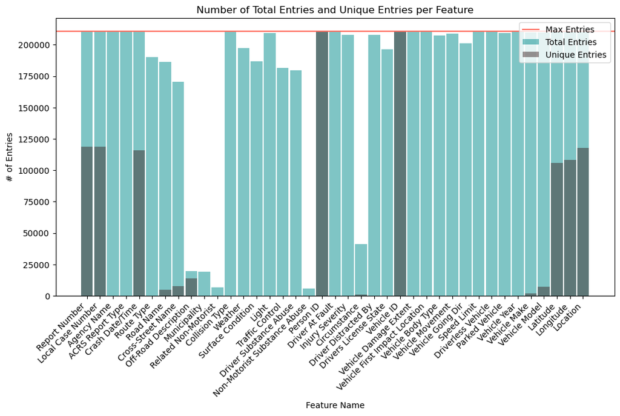

# **MISSING**

### **Understanding the missing values in our data**

```
==============[ N/A Statistics ]==============
Out of 210736 entries, the following number of entries have no values for the columns]

Total Entries: 210736
{
  "Non-Motorist Substance Abuse": 205003,
  "Related Non-Motorist": 203857,
  "Municipality": 191610,
  "Off-Road Description": 191139,
  "Circumstance": 169751,
  "Cross-Street Name": 40448,
  "Driver Substance Abuse": 31320,
  "Traffic Control": 29088,
  "Road Name": 24351,
  "Surface Condition": 23976,
  "Route Type": 20639,
  "Drivers License State": 14350,
  "Weather": 13356,
  "Vehicle Going Dir": 9525,
  "Vehicle Body Type": 3212,
  "Driver Distracted By": 2856,
  "Injury Severity": 2665,
  "Vehicle Movement": 1679,
  "Parked Vehicle": 1526,
  "Light": 1445,
  "Vehicle Model": 1174,
  "Vehicle Make": 1132,
  "Collision Type": 585,
  "Vehicle Damage Extent": 316,
  "Vehicle First Impact Location": 156,
  "Report Number": 0,
  "Local Case Number": 0,
  "Agency Name": 0,
  "ACRS Report Type": 0,
  "Crash Date/Time": 0,
  "Person ID": 0,
  "Driver At Fault": 0,
  "Vehicle ID": 0,
  "Speed Limit": 0,
  "Driverless Vehicle": 0,
  "Vehicle Year": 0,
  "Latitude": 0,
  "Longitude": 0,
  "Location": 0
}
```

#### From the previous results, we can see that the columns `"Non-Motorist Substance Abuse"`, `"Related Non-Motorists"`, `"Municipality"`, `"Off-Road Description"`, `"Circumstance"`, `"Cross-Street Name"`, `"Driver Substance Abuse"`, and `"Traffic Control"` have over 25,000 missing values in the dataset. We can conclude that these columns should be reconsidered in our EDA as their omission would allow us to consider more datapoints.

### **Let's remove these features!**

```
Number of features: 29
```

### **Now that we've filtered the features, lets drop any entries with N/A values**

```
Number of features: 29 and Number of entries: 152393
```

|  | Report Number | Local Case Number | Agency Name | ACRS Report Type | Crash Date/Time | Route Type | Road Name | Collision Type | Weather | Surface Condition | ... | Vehicle Going Dir | Speed Limit | Driverless Vehicle | Parked Vehicle | Vehicle Year | Vehicle Make | Vehicle Model | Latitude | Longitude | Location |
| --- | --- | --- | --- | --- | --- | --- | --- | --- | --- | --- | --- | --- | --- | --- | --- | --- | --- | --- | --- | --- | --- |
| 5 | MCP284600BN | 250037004 | MONTGOMERY | Injury Crash | 08/19/2025 09:50:00 AM | County Route | GRAND PRE RD | Single Vehicle | Rain | Wet | ... | Northbound | 25 | No | No | 2016 | MAZDA | CX-5 | 39.092734 | -77.076470 | (39.09273383, -77.07647) |
| 9 | MCP137801DC | 250034694 | MONTGOMERY | Property Damage Crash | 08/04/2025 03:47:00 PM | Maryland (State) Route | GEORGIA AVE (SB/L) | Front to Rear | Clear | Dry | ... | Eastbound | 35 | No | No | 2018 | FORD | TRANSIT CONNECT | 39.153220 | -77.067015 | (39.15322038, -77.06701504) |
| 11 | MCP3381002W | 250037120 | MONTGOMERY | Property Damage Crash | 08/19/2025 08:35:00 PM | County Route | WISTERIA DR | Front to Rear | Clear | Dry | ... | Southbound | 40 | No | No | 2016 | GILLIG | LOW FLOOR BUS | 39.176935 | -77.270199 | (39.17693504, -77.27019937) |

3 rows × 31 columns

# **OUTLIERS**

### After analyzing the number of missing values in our datatset, we should try to eliminate entries that contain outliers in any of our numerical categories. Taking a look at these categories, we can see that speed limit cannot contain outliers because its a numerical representation of categorical data and our position data cannot contain outliers because they're valid longitude and latitude values within Maryland. This leaves us with `Vehicle Year` to eliminate outliers from.

## Let's start with that:

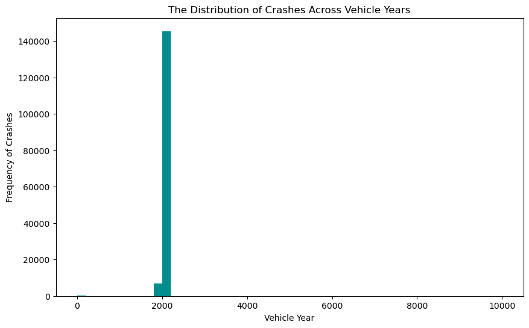

### Hmm... Something seems to be wrong with the distribution of values for `Vehicle Years`. The first problematic observation that can be made is the hump in the 0 bin. This, for obvious reasons, doesn't make sense for vehicle car years. In addition, we can see that the graph has auto-distributed across a range of `(0,10000)`. This tells us that there must be some low-frequency outliers towards the 10,000 mark that's spreading the graph thin.

### **Let's explore this in further detail:**

```
IQR:9.0
We declare points outside of the range 1993 <= x <= 2029 an outlier
This makes the following unique values outliers:
[1111 1992 1990 1988 1987 1977 9999 1989 1991 1984    0 1900 1981 2915
 1983 1966   99 2033  200 1967    3 1975 1980 1978 1969  201 2918  215
 1986 2996 1965 1982 2917 2103 2040 1985 1968 1972 1960 1970   15 1938
 1979 2991 1949 1901 2997  202 1976   97 1971 3013 2914 5005 2911 2201
 1140 1961 1005 1947 2099 1014 2100 1955 2208 1974 2200 1930    8 1963
 2048 2104 1015  198 2919 2055 3003   13 8008 2204 3863 2912    2 1008
   14 1959 1025 2998    4 1234 9000 3012 2109 1957]
```

### **How about we implement a hardcap for the upperbounds?**

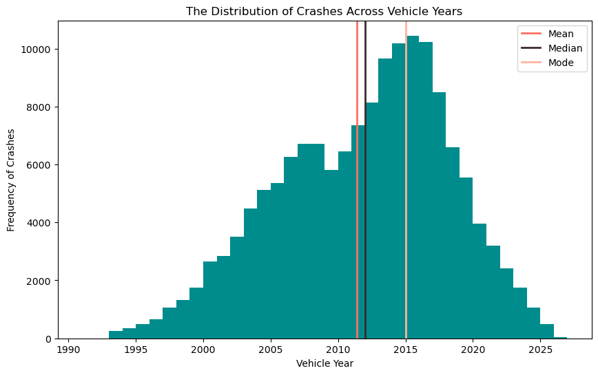

### With this showing promising results, lets drop any rows that fall outsides of the lower, upper range

```
Entries Left: 151366, Entries Deleted: 59370
```

### We can effectively select our lower and upper bounds for outliers by using a modified version of `IQR` outlier selection. We choose to use the lower bound from `IQR` because it provides an accurate representation of the data. For the upper bounds, however, we choose to select the maximum possible valid year for `Vehicle Years`. This allows us to pick the best possible range for outliers.

### In addition, we can conclude that the distribution of `Vehicle Years` is left-skewed since the **Mode > Median > Mean**. Furthermore, we can see that the data is bimodal with peaks at **2008** and **2016**

# **CONVERTING DATATYPES**

#### Some of the datatypes in our features are incorrect, so lets alter them to make them more apporiate for analysis and feature engineering.

#### The first datatype that we should analyze is the `Crash Date/Time`. Currently `Crash Date/Time` is of type string, we should convert this to a `datetime.datetime` object

```
str
```

|  | Report Number | Local Case Number | Agency Name | ACRS Report Type | Crash Date/Time | Route Type | Road Name | Collision Type | Weather | Surface Condition | ... | Speed Limit | Driverless Vehicle | Parked Vehicle | Vehicle Year | Vehicle Make | Vehicle Model | Latitude | Longitude | Location | Crash Datetime |
| --- | --- | --- | --- | --- | --- | --- | --- | --- | --- | --- | --- | --- | --- | --- | --- | --- | --- | --- | --- | --- | --- |
| 5 | MCP284600BN | 250037004 | MONTGOMERY | Injury Crash | 08/19/2025 09:50:00 AM | County Route | GRAND PRE RD | Single Vehicle | Rain | Wet | ... | 25 | No | No | 2016 | MAZDA | CX-5 | 39.092734 | -77.076470 | (39.09273383, -77.07647) | 2025-08-19 09:50:00 |
| 9 | MCP137801DC | 250034694 | MONTGOMERY | Property Damage Crash | 08/04/2025 03:47:00 PM | Maryland (State) Route | GEORGIA AVE (SB/L) | Front to Rear | Clear | Dry | ... | 35 | No | No | 2018 | FORD | TRANSIT CONNECT | 39.153220 | -77.067015 | (39.15322038, -77.06701504) | 2025-08-04 15:47:00 |
| 11 | MCP3381002W | 250037120 | MONTGOMERY | Property Damage Crash | 08/19/2025 08:35:00 PM | County Route | WISTERIA DR | Front to Rear | Clear | Dry | ... | 40 | No | No | 2016 | GILLIG | LOW FLOOR BUS | 39.176935 | -77.270199 | (39.17693504, -77.27019937) | 2025-08-19 20:35:00 |

3 rows × 32 columns

#### The next columns we should look at are the `Driverless Vehicle` column and the `Parked Vehicle` column. Since both of these columns are only yes or no values, we should turn them into a integer representation of boolean values (0 and 1)

|  | Driverless Vehicle | Parked Vehicle | Driver At Fault |
| --- | --- | --- | --- |
| 5 | 0.0 | 0 | 0.0 |
| 9 | 0.0 | 0 | 1.0 |
| 11 | 0.0 | 0 | 0.0 |
| 13 | 0.0 | 0 | 0.0 |
| 14 | 0.0 | 0 | 1.0 |
| ... | ... | ... | ... |
| 210729 | 0.0 | 0 | 0.0 |
| 210730 | 0.0 | 0 | 0.0 |
| 210731 | 0.0 | 0 | 1.0 |
| 210733 | 0.0 | 0 | 1.0 |
| 210734 | 0.0 | 0 | 0.0 |

147975 rows × 3 columns

#### Data in the `Vehicle First Impact Location`, `Vehicle Movement`, and `Vehicle Going Dir` columns needs to be standardized to be all uppercase and without spaces. Additionally any category with under 1000 entries should be eliminated.

|  | Vehicle First Impact Location | Vehicle Movement | Vehicle Going Dir | Injury Severity | Light | Vehicle Damage Extent |
| --- | --- | --- | --- | --- | --- | --- |
| 5 | TWELVEOCLOCK | MOVING CONSTANT SPEED | NORTH | NO APPARENT INJURY | DAYLIGHT | SUPERFICIAL |
| 9 | TWELVEOCLOCK | ACCELERATING | EAST | NO APPARENT INJURY | DAYLIGHT | SUPERFICIAL |
| 11 | SEVENOCLOCK | STOPPED IN TRAFFIC | SOUTH | NO APPARENT INJURY | DARK - LIGHTED | SUPERFICIAL |
| 13 | THREEOCLOCK | MOVING CONSTANT SPEED | WEST | POSSIBLE INJURY | DARK - LIGHTED | FUNCTIONAL |
| 14 | TWOOCLOCK | MOVING CONSTANT SPEED | EAST | NO APPARENT INJURY | DAYLIGHT | DISABLING |

#### Lastly the datatype for our `Location` column looks a little bit odd. When looking at this column, we can see that each of the values is a tuple of the `Latitude` and `Longitude` columns. This indicates that we might be better off removing this column.

|  | Report Number | Local Case Number | Agency Name | ACRS Report Type | Crash Date/Time | Route Type | Road Name | Collision Type | Weather | Surface Condition | ... | Vehicle Going Dir | Speed Limit | Driverless Vehicle | Parked Vehicle | Vehicle Year | Vehicle Make | Vehicle Model | Latitude | Longitude | Crash Datetime |
| --- | --- | --- | --- | --- | --- | --- | --- | --- | --- | --- | --- | --- | --- | --- | --- | --- | --- | --- | --- | --- | --- |
| 5 | MCP284600BN | 250037004 | MONTGOMERY | Injury Crash | 08/19/2025 09:50:00 AM | County Route | GRAND PRE RD | Single Vehicle | Rain | Wet | ... | NORTH | 25 | 0.0 | 0 | 2016 | MAZDA | CX-5 | 39.092734 | -77.076470 | 2025-08-19 09:50:00 |
| 9 | MCP137801DC | 250034694 | MONTGOMERY | Property Damage Crash | 08/04/2025 03:47:00 PM | Maryland (State) Route | GEORGIA AVE (SB/L) | Front to Rear | Clear | Dry | ... | EAST | 35 | 0.0 | 0 | 2018 | FORD | TRANSIT CONNECT | 39.153220 | -77.067015 | 2025-08-04 15:47:00 |
| 11 | MCP3381002W | 250037120 | MONTGOMERY | Property Damage Crash | 08/19/2025 08:35:00 PM | County Route | WISTERIA DR | Front to Rear | Clear | Dry | ... | SOUTH | 40 | 0.0 | 0 | 2016 | GILLIG | LOW FLOOR BUS | 39.176935 | -77.270199 | 2025-08-19 20:35:00 |

3 rows × 31 columns

# **FEATURE ENGINEERING**

#### In order to be able to make more accurate predictions, we should generate our own features to represent complex data patterns that might be present in our data. This could be non-linear patterns such as polynomial patterns or circular patterns. Lets take a look at our data to see what types of complex patterns we can computer for our model

#### One of the complicated numerical features we have is the `Crash Date/Time` column, we might want to extract some key metrics from this data. One of the things we can extract is the time of day, this will allow us to grab insights on whether the target variable is variant to alertness by drivers during certain hours and visible sunlight during certain hours.

|  | Report Number | Local Case Number | Agency Name | ACRS Report Type | Crash Date/Time | Route Type | Road Name | Collision Type | Weather | Surface Condition | ... | Driverless Vehicle | Parked Vehicle | Vehicle Year | Vehicle Make | Vehicle Model | Latitude | Longitude | Crash Datetime | Season | Time of Day |
| --- | --- | --- | --- | --- | --- | --- | --- | --- | --- | --- | --- | --- | --- | --- | --- | --- | --- | --- | --- | --- | --- |
| 5 | MCP284600BN | 250037004 | MONTGOMERY | Injury Crash | 08/19/2025 09:50:00 AM | County Route | GRAND PRE RD | Single Vehicle | Rain | Wet | ... | 0.0 | 0 | 2016 | MAZDA | CX-5 | 39.092734 | -77.076470 | 2025-08-19 09:50:00 | Summer | Morning |
| 9 | MCP137801DC | 250034694 | MONTGOMERY | Property Damage Crash | 08/04/2025 03:47:00 PM | Maryland (State) Route | GEORGIA AVE (SB/L) | Front to Rear | Clear | Dry | ... | 0.0 | 0 | 2018 | FORD | TRANSIT CONNECT | 39.153220 | -77.067015 | 2025-08-04 15:47:00 | Summer | Afternoon |
| 11 | MCP3381002W | 250037120 | MONTGOMERY | Property Damage Crash | 08/19/2025 08:35:00 PM | County Route | WISTERIA DR | Front to Rear | Clear | Dry | ... | 0.0 | 0 | 2016 | GILLIG | LOW FLOOR BUS | 39.176935 | -77.270199 | 2025-08-19 20:35:00 | Summer | Evening |

3 rows × 33 columns

Let's test the time of day column to see if the frequency of crashes is dependent on the `Time of Day`

|  | Morning | Afternoon | Evening | Night |
| --- | --- | --- | --- | --- |
| 0 | 42654 | 46023 | 31809 | 16369 |

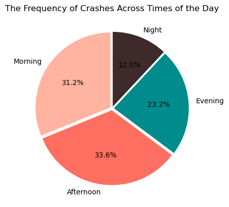

After examining this graph, we have reason to believe there is a connection between crashes and times of the day. To test this hypothesis lets use the chi-squared test:

Using the significance level of $\alpha = 0.05$

- HO: The frequency of crashes is equally distributed across `Time of Day`
- HA: The frequency of crashes is not equally distributed across `Time of Day`

```
Chi-square Statistic: 15634.478265317306
p-value: 0.0
```

#### Since this p-value is less than the significance level **(0.0 < 0.05)**, we can reject the Null Hypothesis(**HO**) and conclude that the frequency of crashes cannot be equally distributed across `Time of Day`

#### Another feature that we can extract from the data is the Area of the Crash. Based on the speed limit, we can derive where the crash took place. We use a simple heuristic to determine where the crash takes place. If x<=15 its in an alley, if x<=35 its a residential, if x<=55 its a highway, otherwise its an interstate. This allows us to bin the numerical data into meaningful categories that can be used for analysis later on.

|  | Report Number | Local Case Number | Agency Name | ACRS Report Type | Crash Date/Time | Route Type | Road Name | Collision Type | Weather | Surface Condition | ... | Parked Vehicle | Vehicle Year | Vehicle Make | Vehicle Model | Latitude | Longitude | Crash Datetime | Season | Time of Day | Crash Area |
| --- | --- | --- | --- | --- | --- | --- | --- | --- | --- | --- | --- | --- | --- | --- | --- | --- | --- | --- | --- | --- | --- |
| 5 | MCP284600BN | 250037004 | MONTGOMERY | Injury Crash | 08/19/2025 09:50:00 AM | County Route | GRAND PRE RD | Single Vehicle | Rain | Wet | ... | 0 | 2016 | MAZDA | CX-5 | 39.092734 | -77.076470 | 2025-08-19 09:50:00 | Summer | Morning | Residential |
| 9 | MCP137801DC | 250034694 | MONTGOMERY | Property Damage Crash | 08/04/2025 03:47:00 PM | Maryland (State) Route | GEORGIA AVE (SB/L) | Front to Rear | Clear | Dry | ... | 0 | 2018 | FORD | TRANSIT CONNECT | 39.153220 | -77.067015 | 2025-08-04 15:47:00 | Summer | Afternoon | Residential |
| 11 | MCP3381002W | 250037120 | MONTGOMERY | Property Damage Crash | 08/19/2025 08:35:00 PM | County Route | WISTERIA DR | Front to Rear | Clear | Dry | ... | 0 | 2016 | GILLIG | LOW FLOOR BUS | 39.176935 | -77.270199 | 2025-08-19 20:35:00 | Summer | Evening | Highway |

3 rows × 34 columns

#### We also need to create a combined variable for Vehicle Mode and Vehicle Make. It makes more sense to combine these values and use for comparison because they are heavily linked.

```
11374
```

|  | Report Number | Local Case Number | Agency Name | ACRS Report Type | Crash Date/Time | Route Type | Road Name | Collision Type | Weather | Surface Condition | ... | Vehicle Year | Vehicle Make | Vehicle Model | Latitude | Longitude | Crash Datetime | Season | Time of Day | Crash Area | MakeModel |
| --- | --- | --- | --- | --- | --- | --- | --- | --- | --- | --- | --- | --- | --- | --- | --- | --- | --- | --- | --- | --- | --- |
| 5 | MCP284600BN | 250037004 | MONTGOMERY | Injury Crash | 08/19/2025 09:50:00 AM | County Route | GRAND PRE RD | Single Vehicle | Rain | Wet | ... | 2016 | MAZDA | CX-5 | 39.092734 | -77.076470 | 2025-08-19 09:50:00 | Summer | Morning | Residential | MAZDA_CX-5 |
| 9 | MCP137801DC | 250034694 | MONTGOMERY | Property Damage Crash | 08/04/2025 03:47:00 PM | Maryland (State) Route | GEORGIA AVE (SB/L) | Front to Rear | Clear | Dry | ... | 2018 | FORD | TRANSIT CONNECT | 39.153220 | -77.067015 | 2025-08-04 15:47:00 | Summer | Afternoon | Residential | FORD_TRANSIT CONNECT |
| 11 | MCP3381002W | 250037120 | MONTGOMERY | Property Damage Crash | 08/19/2025 08:35:00 PM | County Route | WISTERIA DR | Front to Rear | Clear | Dry | ... | 2016 | GILLIG | LOW FLOOR BUS | 39.176935 | -77.270199 | 2025-08-19 20:35:00 | Summer | Evening | Highway | GILLIG_LOW FLOOR BUS |

3 rows × 35 columns

### **WOAH!**

#### The number of classes in our feature suddenly jumped to over 10,000. This clearly won't work for our analysis since high cardinality data will be very difficult to use for predictions. We should take some steps to limit the number of feature classes.

```
96
```

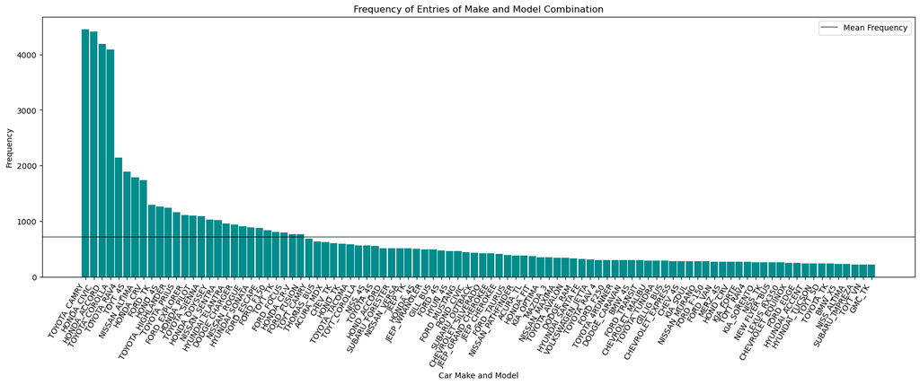

#### After finding the distribution of the remaining car make and models, we should look at number of remaining datapoints to ensure they have not dipped below a reasonable amount.

```
The filtered dataset has 68872 entries and 35 columns
Column Names: ['Report Number', 'Local Case Number', 'Agency Name', 'ACRS Report Type', 'Crash Date/Time', 'Route Type', 'Road Name', 'Collision Type', 'Weather', 'Surface Condition', 'Light', 'Person ID', 'Driver At Fault', 'Injury Severity', 'Driver Distracted By', 'Drivers License State', 'Vehicl…
96
```

#### Finally, we need to map our target variable such that we create distinct classes for our prediction. We can accomplish this by mapping the minor classes to larger/broader classes. We can split the 5 existing classes into 3 classes.

|  | Report Number | Local Case Number | Agency Name | ACRS Report Type | Crash Date/Time | Route Type | Road Name | Collision Type | Weather | Surface Condition | ... | Vehicle Year | Vehicle Make | Vehicle Model | Latitude | Longitude | Crash Datetime | Season | Time of Day | Crash Area | MakeModel |
| --- | --- | --- | --- | --- | --- | --- | --- | --- | --- | --- | --- | --- | --- | --- | --- | --- | --- | --- | --- | --- | --- |
| 14 | MCP2723009V | 250037762 | MONTGOMERY | Injury Crash | 08/23/2025 06:20:00 PM | County Route | PEBBLESTONE DR | Front to Front | Clear | Dry | ... | 2015 | JEEP | CHEROKEE | 39.090965 | -77.019478 | 2025-08-23 18:20:00 | Summer | Evening | Residential | JEEP_CHEROKEE |
| 15 | MCP2349001B | 250037516 | MONTGOMERY | Property Damage Crash | 08/22/2025 10:44:00 AM | Interstate (State) | EISENHOWER MEMORIAL HWY | Single Vehicle | Clear | Dry | ... | 2017 | CHEVROLET | MALIBU | 39.180181 | -77.250657 | 2025-08-22 10:44:00 | Summer | Morning | Highway | CHEVROLET_MALIBU |
| 18 | DM8386002B | 250037144 | TAKOMA | Property Damage Crash | 08/20/2025 03:15:00 AM | Municipality Route | SYCAMORE AVE | Front to Rear | Rain | Wet | ... | 2021 | HONDA | CR-V | 38.978059 | -77.005619 | 2025-08-20 03:15:00 | Summer | Night | Residential | HONDA_CR-V |

3 rows × 35 columns

# **FEATURE SELECTION**

### In order to explore the relationships between our categorical features, we might opt to use a correlation heatmap. This type of graph can display the effective relationships between variables, which variables might be redundant, and allows us to pick the most useful features for future exploration.

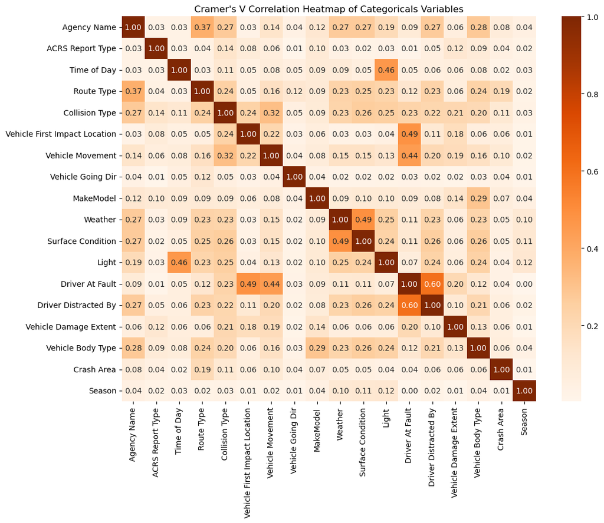

.

### **Next lets take a look at the correlation between each categorical feature and the target variable**

```
 Columns Driver Distracted By and Driver At Fault have a Cramer's coefficient of 0.5990450610302714
 Columns Surface Condition and Weather have a Cramer's coefficient of 0.4925992316142331
 Columns Driver At Fault and Vehicle First Impact Location have a Cramer's coefficient of 0.48525238834873713
 Columns Light and Time of Day have a Cramer's coefficient of 0.4587608153882699
 Columns Driver At Fault and Vehicle Movement have a Cramer's coefficient of 0.4444206707767687
 Columns Route Type and Agency Name have a Cramer's coefficient of 0.37456357344140956
```

### **Conclusion**

#### **It's important to note** that we cannot conlude that these variables are positively or negatively correlated, only that knowing one can be a meaningful way of predicting the other.

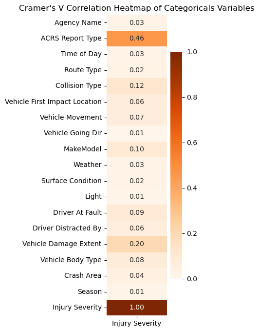

```
 Columns ACRS Report Type and Injury Severity have a Cramer's coefficient of 0.46161124089461386
```

### **Conclusion**

#### **It's important to note** that we cannot conlude that these variables are positively or negatively correlated, only that knowing one can be a meaningful way of predicting the other.

# **ML Algorithm Design/Development (Part D)**

# **ML Algorithm Training and Test Data Analysis (Part E)**

```
Number of training entries: 55097
Number of testing entries: 13775
Percent of entries that are form training: 79.99912881867812%
```

[output not shown]

```
+=============Random Forest Classifier=============+
Overall Accuracy: 85.822%
Weighted F1-Score: 0.853
--- Detailed Classification Report ---
                precision    recall  f1-score   support

MINOR/MODERATE       0.68      0.65      0.66      2910
     NO INJURY       0.90      0.92      0.91     10744
  SEVERE/FATAL       0.00      0.00      0.00       121

      accuracy                           0.86     13775
     macro avg       0.53      0.53      0.53     13775
  weighted avg       0.85      0.86      0.85     13775

+=============Logistic Regression=============+
Overall Accuracy: 86.461%
Weighted F1-Score: 0.864
--- Detailed Classification Report ---
                precision    recall  f1-score   support

MINOR/MODERATE       0.67      0.72      0.70      2910
     NO INJURY       0.92      0.91      0.92     10744
  SEVERE/FATAL       0.65      0.11      0.18       121

      accuracy                           0.86     13775
     macro avg       0.75      0.58      0.60     13775
  weighted avg       0.87      0.86      0.86     13775

+=============CatBoost Classifier=============+
Overall Accuracy: 86.548%
Weighted F1-Score: 0.867
--- Detailed Classification Report ---
                precision    recall  f1-score   support

MINOR/MODERATE       0.66      0.77      0.71      2910
     NO INJURY       0.94      0.90      0.92     10744
  SEVERE/FATAL       0.59      0.08      0.14       121

      accuracy                           0.87     13775
     macro avg       0.73      0.59      0.59     13775
```

[output cut: 14 more lines]

```
  weighted avg       0.87      0.86      0.87     13775

+=============XGBClassifier=============+
Overall Accuracy: 86.069%
Weighted F1-Score: 0.861
--- Detailed Classification Report ---
                precision    recall  f1-score   support

MINOR/MODERATE       0.65      0.76      0.70      2910
     NO INJURY       0.93      0.90      0.91     10744
  SEVERE/FATAL       0.67      0.07      0.12       121

      accuracy                           0.86     13775
     macro avg       0.75      0.57      0.58     13775
  weighted avg       0.87      0.86      0.86     13775
```

# **Visualization, Result Analysis, Conclusion (Part F)**